# The University of North Carolina at Chapel Hill

# Comp 555 BioAlgorithms - Spring 2019

# Problem Set #1

# Version 2.0

# Issued Tuesday, 1/22/2019; Due Tuesday, 2/5/2019

**Homework Information:** Some of the problems are probably too long to be done the night before the due date, so plan accordingly. Late problem sets will be penalized by a factor of 70.71% for each class meeting after the due date. Feel free to get help from others, but **the work you submit in should be your own.** It is very important that you enter your answers in the provided cells. You can add extra cells to explore approaches, but only the provided cell can and will be graded.

**Warning:** This notebook has been annotated with metadata so that it can be uploaded to the grading system. Thus, if you delete a cell and add a replacement, there is a possiblity that your problem will not be graded. If you ever need to start over, you should download a new version of the problem set and transfer your solutions to it.

```python
# Replace the following string values with the requested information
# Leave the quotation marks surronding the string!
class Student:
    first = "Benjamin"
    last = "Fawcett"
    onyen = "bfawcett"
    pid = "730095208"
```

This problem set will examine two genomes GenomeA.fa and GenomeB.fa. One is the genome of an actual organism, the other is a random seqence of nucleotides. Some answers are provided in order to test your code for the genome of ThermotogaPetrophila.fa from Lecture 3.

The cell below provides various functions and imports necessary for this problem set. Do not import any addtional packages. Also, make sure that you *run the following cell*.

```python
import gzip
import itertools
import math
%matplotlib inline
import matplotlib
import matplotlib.pyplot as plt

def loadFasta(filename):
    """ Parses a classically formatted and possibly
        compressed FASTA file into two lists. One of
        headers and a second list of sequences.
        The ith index of each list correspond."""
    if (filename.endswith(".gz")):
        fp = gzip.open(filename, 'r')
    else:
        fp = open(filename, 'r')
    # split at headers
    data = fp.read().split('>')
    fp.close()
    # ignore whatever appears before the 1st header
    data.pop(0)
    headers = []
    sequences = []
    for sequence in data:
        lines = sequence.split('\n')
        headers.append(lines.pop(0))
        # add an extra "+" to make string "1-referenced"
        sequences.append('+' + ''.join(lines))
    return (headers, sequences)
```

**Problem #1:**

Write a function to find the length of the shortest *missing* *k*-mer in a given genome. Your function should return a value for *k*, the number of *k*-mers missing (must be 1 or greater). A template for the function is provided in the cell below. This cell should include *only your function* definition. A cell for testing is provided after.

```python
# This cell is graded
def shortestMissingKmer(seq):
    """ Returns the value of k for the shortest missing
         k-mer, and a list of all such k-mers"""
    k, missing = 0, 0
    original = seq
    bases = ['A', 'T', 'C', 'G']

    allKmers = True
    kmers = bases
    k = 1


    while (allKmers):
        seq = original + original[1:k-1]
        kmerDict = {}
        for i in range(1,len(seq)-k+1):
            kmer = seq[i:i+k]
            kmerDict[kmer] = kmerDict.get(kmer,0) + 1


        if (4**k - len(kmerDict) != 0):
            missing = 4**k - len(kmerDict)
            allKmers = False
        else:
            k += 1



    return k, missing
```

The following cell below is provided for testing your code. You should test it on both GenomeA and GenomeB. This cell will not be considered during grading.

```python
header, sequence = loadFasta("data/ThermotogaPetrophila.fa")
header, sequenceA = loadFasta("data/GenomeA.fa")
header, sequenceB = loadFasta("data/GenomeB.fa")


k, m = shortestMissingKmer(sequence[0])
kA, mA = shortestMissingKmer(sequenceA[0])
kB, mB = shortestMissingKmer(sequenceB[0])
# The correct answer is: (7, 4)

print("Thermotoga Petrophila's shortest missing k-mer is a " + str(k) + "-mer and there are " + str(m) + " " + str(k) + "-mers missing.")
print("Genome A's shortest missing k-mer is a " + str(kA) + "-mer and there are " + str(mA) + " " + str(kA) + "-mers missing.")
print("Genome B's shortest missing k-mer is a " + str(kB) + "-mer and there are " + str(mB) + " " + str(kB) + "-mers missing.")
```

```
Thermotoga Petrophila's shortest missing k-mer is a 7-mer and there are 4 7-mers missing.
Genome A's shortest missing k-mer is a 9-mer and there are 225 9-mers missing.
Genome B's shortest missing k-mer is a 8-mer and there are 442 8-mers missing.
```

**Problem #2:**

Write a function that returns a list of the number of k-mers that appear N times for a given value of k (i.e. how many k-mers appear 0 times, 1 time, 2 times, 3 times ...) where the *i*-th element in the list is the number of kmers appearing *i* times. The length of your list need only be as long as the most frequent k-mer. Take the result from your function and plot a histogram of the k-mer frequencies for GenomeA and GenomeB.

A template for the function is provided in the cell below. Once more, only include your function definition in the cell below.

```python
# This cell is graded
def kmerFrequency(seq, k):
    seq = seq + seq[1:k-1]
    NList = []
    # ~Your code goes here~
    kmerDict = {}
    for i in range(1,len(seq)-k+1):
        kmer = seq[i:i+k]
        kmerDict[kmer] = kmerDict.get(kmer,0) + 1

    listSize = max(list(kmerDict.values()))+1
    NList = [0]*listSize

    NList[0] = 4**k - len(kmerDict)

    for x in list(kmerDict.values()):
        NList[x] += 1
    return NList
```

Use the following cell to test your function. Run it on GenomeA and GenomeB, and plot separate k-mer frequencies for each on a semilog scale.

```
### Thermotoga Petrophila ###
1083
386
149
66
48
43
42
42


### Genome A ###
157
58
23
11
7
7
5
4


### Genome B ###
1100
391
157
65
30
17
11
10
```

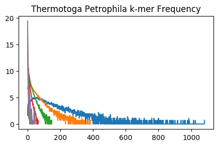

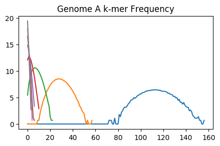

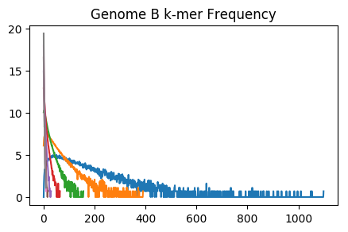

```python
header, sequence = loadFasta("data/ThermotogaPetrophila.fa")


print("### Thermotoga Petrophila ###")

for k in range(7,15):
    hist = kmerFrequency(sequence[0], k)
    tot = 0
    for x in hist:
        tot += x
    print(len(hist))
    plt.figure(num=1, figsize=(5, 3), dpi=100)
    plt.plot(range(len(hist)), [math.log(v+1) for v in hist])
    plt.title("Thermotoga Petrophila k-mer Frequency", fontdict=None, loc='center', pad=None)

print("")
print("")

header, sequenceA = loadFasta("data/GenomeA.fa")
header, sequenceB = loadFasta("data/GenomeB.fa")


print("### Genome A ###")
for k in range(7,15):
    hist = kmerFrequency(sequenceA[0], k)
    tot = 0
    for x in hist:
        tot += x
    print(len(hist))
    plt.figure(num=2, figsize=(5, 3), dpi=100)
    plt.plot(range(len(hist)), [math.log(v+1) for v in hist])
    plt.title("Genome A k-mer Frequency", fontdict=None, loc='center', pad=None)

print("")
print("")

print("### Genome B ###")
for k in range(7,15):
    hist = kmerFrequency(sequenceB[0], k)
    tot = 0
    for x in hist:
        tot += x
    print(len(hist))
    plt.figure(num=3, figsize=(5, 3), dpi=100)
    plt.plot(range(len(hist)), [math.log(v+1) for v in hist])
    plt.title("Genome B k-mer Frequency", fontdict=None, loc='center', pad=None)
```

A correct implementation of kmerFrequency() when called by the following code:

```
header, sequence = loadFasta("data/ThermotogaPetrophila.fa")

for k in xrange(7,15):
    hist = kmerFrequency(sequence[0], k)
    print len(hist)
    plt.plot(range(len(hist)), [math.log(v+1) for v in hist])
```

should generate the following outputs:

1083  
386  
149  
66  
48  
43  
42  
42

[figure not shown]

**Problem #3:**

Use your kmerFrequency() function from Problem #2 to find the smallest value of k where the number of non-repeated k-mers is more than 90% of the k-mers in the genome.

```python
# This cell is graded
def nonrepeatingKmers(seq):
    unique90 = 0
    notFound = True
    i = 1

    while notFound:
        output = kmerFrequency(seq,i)
        denom = 0
        for x in range(1,len(output)-1):
            denom += x*output[x]

        if ((output[1]/denom) > 0.9):
            unique90 = i
            notFound = False
        else:
            i += 1

    return unique90
```

Use the following Cell to test your function.

```python
header, sequence = loadFasta("data/ThermotogaPetrophila.fa")
header, sequenceA = loadFasta("data/GenomeA.fa")
header, sequenceB = loadFasta("data/GenomeB.fa")


print("90%+ of " + str(nonrepeatingKmers(sequence[0])) + "-mers are unique in Thermotoga Petrophila.")
print("90%+ of " + str(nonrepeatingKmers(sequenceA[0])) + "-mers are unique in Genome A.")
print("90%+ of " + str(nonrepeatingKmers(sequenceB[0])) + "-mers are unique in Genome B.")
```

```
90%+ of 14-mers are unique in Thermotoga Petrophila.
90%+ of 13-mers are unique in Genome A.
90%+ of 14-mers are unique in Genome B.
```

**Problem #4:**

Plot the C-G skew plot as shown in class for both GenomeA and GenomeB. Plot the result and use the returned array of counts to estimate a 1000-bp interval that you would predict to contain the *OriR* locus. In the cell below enter your code to plot the C-G skew plots and your prediction of the *OriR* interval for both GenomeA and GenomeB.

```
OriR for Thermotoga Petrophila is likely in the 1,000 bp region from 785338 to 786338
OriR for Genome A is likely in the 1,000 bp region from 1269591 to 1270591
OriR for Genome B is likely in the 1,000 bp region from 2322 to 3322
```

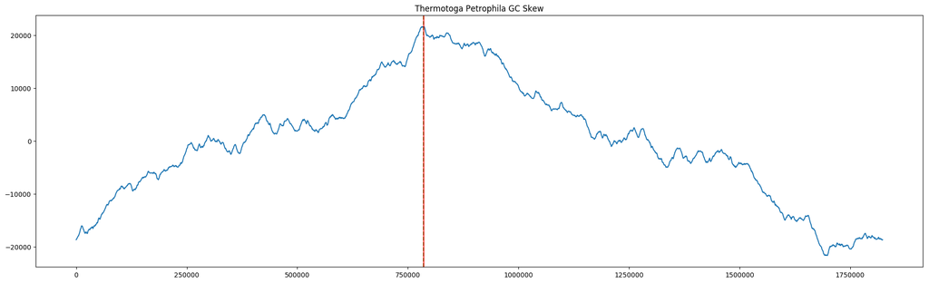

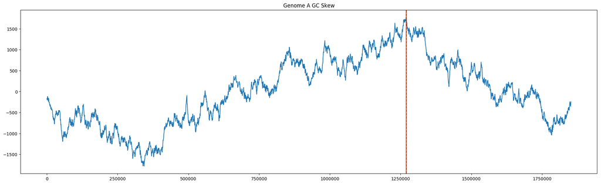

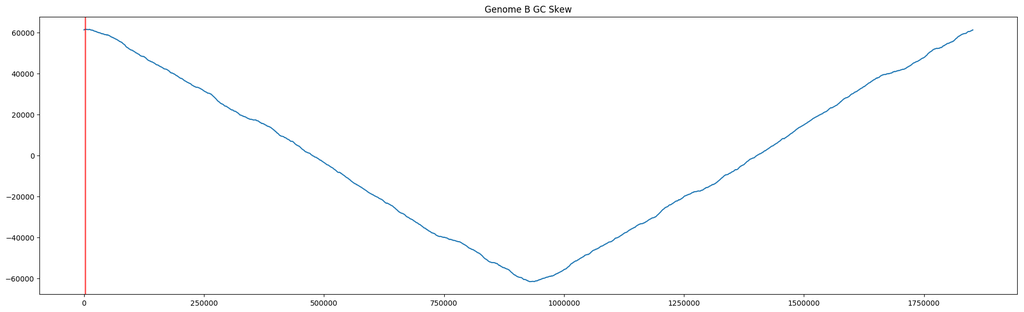

```python
# This cell is graded
header, sequence = loadFasta("data/ThermotogaPetrophila.fa")
headerA, sequenceA = loadFasta("data/GenomeA.fa")
headerB, sequenceB = loadFasta("data/GenomeB.fa")

def getGCdiff(sequence, start):
    halflen = len(sequence)//2
    terC = start + halflen
    # handle genome's circular nature
    if (terC > len(sequence)):
        terC = terC - len(sequence) + 1
    if (start <= 0):
        start = start + len(sequence) - 1
    if (start > len(sequence)):
        start = start - len(sequence) + 1
    if (terC <= 0):
        terC = terC + len(sequence) - 1
    if (start == 0):
        start = 1
    if (terC > start):                                   # case 1: ----S========T---->
        G = 2*sequence[start:terC].count('G') - sequence.count('G')
        C = 2*sequence[start:terC].count('C') - sequence.count('C')
    else:                                                # case 2: ====T--------S====>
        G = sequence.count('G') - 2*sequence[terC:start].count('G')
        C = sequence.count('C') - 2*sequence[terC:start].count('C')
    return start, (G - C)

def GCSkew(genome):
    x = []
    y = []
    for i in range(1,len(genome),500):
        addx, addy = getGCdiff(genome, i)
        x.append(addx)
        y.append(addy)
    return x, y



def findOriR(genome, gcMax):
    xSmall = []
    ySmall = []
    for i in range(gcMax-750, gcMax+750, 1):
        addx, addy = getGCdiff(genome, i)
        xSmall.append(addx)
        ySmall.append(addy)


    xLow = xSmall[ySmall.index(max(ySmall))] - 500
    xHigh = xSmall[ySmall.index(max(ySmall))] + 500

    if (xLow <= 0):
        xLow = xLow + len(genome) - 1
    if (xLow >= len(genome)-1):
        xLow = xLow - (len(genome)-1)

    if (xHigh <= 0):
        xHigh = xHigh + len(genome) - 1
    if (xHigh >= len(genome)-1):
        xHigh = xHigh - (len(genome)-1)

    return xSmall, ySmall, xLow, xHigh

#Thermotoga Petrophila
x, y = GCSkew(sequence[0])

plt.figure(num=None, figsize=(24, 7), dpi=100)
plt.title("Thermotoga Petrophila GC Skew", fontdict=None, loc='center', pad=None)
result = plt.plot(x, y)

yargmax = y.index(max(y))
gcMax = x[yargmax]

x,y,xLow,xHigh = findOriR(sequence[0],gcMax)
plt.axvline(x[y.index(max(y))], color="g", linestyle='--')
plt.axvline(xLow, color='red', alpha=0.5)
plt.axvline(xHigh, color='red', alpha=0.5)
print("OriR for Thermotoga Petrophila is likely in the 1,000 bp region from " + str(xLow) + " to " + str(xHigh))


#Genome A
x, y = GCSkew(sequenceA[0])

plt.figure(num=None, figsize=(24, 7), dpi=100)
plt.title("Genome A GC Skew", fontdict=None, loc='center', pad=None)
result = plt.plot(x, y)

yargmax = y.index(max(y))
gcMax = x[yargmax]

x,y,xLow,xHigh = findOriR(sequenceA[0],gcMax)
plt.axvline(x[y.index(max(y))], color="g", linestyle='--')
plt.axvline(xLow, color='red', alpha=0.5)
plt.axvline(xHigh, color='red', alpha=0.5)
print("OriR for Genome A is likely in the 1,000 bp region from " + str(xLow) + " to " + str(xHigh))


#Genome B

x, y = GCSkew(sequenceB[0])

plt.figure(num=None, figsize=(24, 7), dpi=100)
plt.title("Genome B GC Skew", fontdict=None, loc='center', pad=None)
result = plt.plot(x, y)

yargmax = y.index(max(y))
gcMax = x[yargmax]

x,y,xLow,xHigh = findOriR(sequenceB[0],gcMax)
plt.axvline(xLow, color='red', alpha=0.5)
plt.axvline(xHigh, color='red', alpha=0.5)
print("OriR for Genome B is likely in the 1,000 bp region from " + str(xLow) + " to " + str(xHigh))
```

Many examples related to C-G skew can be found in the Lecture 3 notebook.

**Problem #5:**

Consider the tools that you have developed in problems 1-4 to predict which of GenomeA and GenomeB is real. In the cell provided below explain your reasoning as it relates to each tool.

#This cell is graded The data for GenomeA suggests that it is the randomly generated genome data set. Genome A has a full set of possible 8-mers, which is unlike Genome B, which has 442 8-mers missing. This makes sense, because if Genome A was truly "randomly generated," then it is indeed more likely to have a longer length for the shortest missing k-mer than a functional genome with patterns encoding important cell functionality. Genome A also has more normal distributions of the frequency of k-mers 7-15, whereas the Genome B and Thermotoga Petrophilus both have very similar distributions, with several higher -degree k-mers being present at high frequencies. Finally, the Genome A GC skew is vastly condensed (+/- 1500) compared to those of Genome B and the Thermotoga Petrophilus, indicating that the composition of the genome is not optimized for functionality, but rather by an algorithm that causes there to be a fairly evenly spread distribution of nucleotide sequences.

## Instructions for submitting your problem set

When you are ready to submit a version of your problem set, follow the instructions below.

1. Press [Save and Checkpoint] on the *File* menu of your Jupyter notebook.
2. Press the link below, which will take you to a website for submitting your problem set.
3. Choose the *correct problem set number* from the pull-down, else you might overwrite an earlier submission.
4. Enter in your onyen and PID in the form provided, then upload your submission.

Click [here to submit](http://csbio.unc.edu/mcmillan/index.py?run=PS.upload) your completed problem set

**Instructions for resubmissions:**

1. You may resubmit as many times as you like before the deadline.
2. Resubmissions *always* overwrite any earlier submissions.
3. If you resubmit after the due date, you will be warned of any penalties.
4. Problem sets will not be regraded.